# E-commerce Customer Behavior Analysis: Predicting Purchases

Hamdan

2024-11-22

## Background of the project:

In today’s digital world, e-commerce plays a huge role in how people shop. Understanding what drives online shoppers to make a purchase is key for businesses looking to stay competitive. This project focuses on exploring the Online Shoppers Purchasing Intention Dataset, a rich collection of data from over 12,000 unique website sessions recorded over a year. By analyzing this dataset, we can get a clearer picture of how visitors interact with an e-commerce site and what factors influence their buying decisions.

The dataset includes details like the time visitors spend on different types of pages, how often they leave after viewing just one page, the impact of special days, and even technical details like the browser or operating system they use. The main goal is to figure out what separates sessions that lead to purchases from those that don’t.

The project aims to analyze a comprehensive e-commerce dataset to gain insights into customer behavior and develop predictive models for purchase likelihood. I will explore various factors influencing online shopping behavior, including visitor type (new vs. returning), time spent on site, page views.

## Data source

https://archive.ics.uci.edu/dataset/468/online+shoppers+purchasing+intention+dataset

The dataset consists of feature vectors belonging to 12,330 sessions. The dataset was formed so that each session would belong to a different user in a 1-year period to avoid any tendency to a specific campaign, special day, user profile, or period.

The definitions of the columns are:

- Month:(Categorical) - Month of the year when the session occurred.
- OperatingSystems: (Integer) - Operating system used by the visitor, encoded as integers.
- Browser: (Integer) - Browser used by the visitor, encoded as integers.
- Region: (Integer) - Geographic region of the visitor, encoded as integers.
- TrafficType: (Integer) - Source of traffic, encoded as integers.
- VisitorType: (Categorical) - Visitor type (Returning or New).
- Weekend: (Binary) - Indicates if the session was on a weekend (true/false).
- Revenue: Target (Binary) - Indicates if the session resulted in a transaction (true / false).
- Administrative: (Integer) - Number of administrative pages visited.
- Administrative_Duration: (Integer) - Total time spent on administrative pages (seconds).
- Informational: (Integer) - Number of informational pages visited.
- Informational_Duration: Feature (Integer) - Total time spent on informational pages (seconds).
- ProductRelated: (Integer) - Number of product-related pages visited.
- ProductRelated_Duration: (Continuous) - Total time spent on product-related pages (seconds).
- BounceRates: (Continuous) - Percentage of visitors who left after viewing only one page.
- ExitRates: (Continuous) - Percentage of times a page was the last page viewed.
- PageValues: (Continuous) - Average value of a page based on pre-transaction visits.
- SpecialDay: (Continuous) - Proximity of the visit to a special day, ranging from 0 to 1

# Load necessary libraries

```r
library(caret)
```

```r
library(ggplot2)
library(lattice)
library(skimr)
library(dplyr)
library(randomForest)
library(class)
library(tidyr)
library(stringr)
library(scales)
library(plotly)
library(forcats)
library(rpart)
library(rpart.plot)
library(ROSE)
```

# Import the data

```r
data <- read.csv('data/online_shoppers_intention.csv' , stringsAsFactors = TRUE)
```

# Get a summary of the dataset

Using the `skim` function to understand the summary of all the variables

```r
skim(data)
```

Data summary

| Name | data |
| --- | --- |
| Number of rows | 12330 |
| Number of columns | 18 |
| _______________________ |  |
| Column type frequency: |  |
| factor | 2 |
| logical | 2 |
| numeric | 14 |
| ________________________ |  |
| Group variables | None |

**Variable type: factor**

| skim_variable | n_missing | complete_rate | ordered | n_unique | top_counts |
| --- | --- | --- | --- | --- | --- |
| Month | 0 | 1 | FALSE | 10 | May: 3364, Nov: 2998, Mar: 1907, Dec: 1727 |
| VisitorType | 0 | 1 | FALSE | 3 | Ret: 10551, New: 1694, Oth: 85 |

**Variable type: logical**

| skim_variable | n_missing | complete_rate | mean | count |
| --- | --- | --- | --- | --- |
| Weekend | 0 | 1 | 0.23 | FAL: 9462, TRU: 2868 |
| Revenue | 0 | 1 | 0.15 | FAL: 10422, TRU: 1908 |

**Variable type: numeric**

| skim_variable | n_missing | complete_rate | mean | sd | p0 | p25 | p50 | p75 | p100 | hist |
| --- | --- | --- | --- | --- | --- | --- | --- | --- | --- | --- |
| Administrative | 0 | 1 | 2.32 | 3.32 | 0 | 0.00 | 1.00 | 4.00 | 27.00 | ▇▁▁▁▁ |
| Administrative_Duration | 0 | 1 | 80.82 | 176.78 | 0 | 0.00 | 7.50 | 93.26 | 3398.75 | ▇▁▁▁▁ |
| Informational | 0 | 1 | 0.50 | 1.27 | 0 | 0.00 | 0.00 | 0.00 | 24.00 | ▇▁▁▁▁ |
| Informational_Duration | 0 | 1 | 34.47 | 140.75 | 0 | 0.00 | 0.00 | 0.00 | 2549.38 | ▇▁▁▁▁ |
| ProductRelated | 0 | 1 | 31.73 | 44.48 | 0 | 7.00 | 18.00 | 38.00 | 705.00 | ▇▁▁▁▁ |
| ProductRelated_Duration | 0 | 1 | 1194.75 | 1913.67 | 0 | 184.14 | 598.94 | 1464.16 | 63973.52 | ▇▁▁▁▁ |
| BounceRates | 0 | 1 | 0.02 | 0.05 | 0 | 0.00 | 0.00 | 0.02 | 0.20 | ▇▁▁▁▁ |
| ExitRates | 0 | 1 | 0.04 | 0.05 | 0 | 0.01 | 0.03 | 0.05 | 0.20 | ▇▂▁▁▁ |
| PageValues | 0 | 1 | 5.89 | 18.57 | 0 | 0.00 | 0.00 | 0.00 | 361.76 | ▇▁▁▁▁ |
| SpecialDay | 0 | 1 | 0.06 | 0.20 | 0 | 0.00 | 0.00 | 0.00 | 1.00 | ▇▁▁▁▁ |
| OperatingSystems | 0 | 1 | 2.12 | 0.91 | 1 | 2.00 | 2.00 | 3.00 | 8.00 | ▇▂▁▁▁ |
| Browser | 0 | 1 | 2.36 | 1.72 | 1 | 2.00 | 2.00 | 2.00 | 13.00 | ▇▁▁▁▁ |
| Region | 0 | 1 | 3.15 | 2.40 | 1 | 1.00 | 3.00 | 4.00 | 9.00 | ▇▅▁▂▁ |
| TrafficType | 0 | 1 | 4.07 | 4.03 | 1 | 2.00 | 2.00 | 4.00 | 20.00 | ▇▁▁▁▁ |

Using the `str` function to understand the data types of each of the variables

```r
str(data)
```

```
## 'data.frame':    12330 obs. of  18 variables:
##  $ Administrative         : int  0 0 0 0 0 0 0 1 0 0 ...
##  $ Administrative_Duration: num  0 0 0 0 0 0 0 0 0 0 ...
##  $ Informational          : int  0 0 0 0 0 0 0 0 0 0 ...
##  $ Informational_Duration : num  0 0 0 0 0 0 0 0 0 0 ...
##  $ ProductRelated         : int  1 2 1 2 10 19 1 0 2 3 ...
##  $ ProductRelated_Duration: num  0 64 0 2.67 627.5 ...
##  $ BounceRates            : num  0.2 0 0.2 0.05 0.02 ...
##  $ ExitRates              : num  0.2 0.1 0.2 0.14 0.05 ...
##  $ PageValues             : num  0 0 0 0 0 0 0 0 0 0 ...
##  $ SpecialDay             : num  0 0 0 0 0 0 0.4 0 0.8 0.4 ...
##  $ Month                  : Factor w/ 10 levels "Aug","Dec","Feb",..: 3 3 3 3 3 3 3 3 3 3 ...
##  $ OperatingSystems       : int  1 2 4 3 3 2 2 1 2 2 ...
##  $ Browser                : int  1 2 1 2 3 2 4 2 2 4 ...
##  $ Region                 : int  1 1 9 2 1 1 3 1 2 1 ...
##  $ TrafficType            : int  1 2 3 4 4 3 3 5 3 2 ...
##  $ VisitorType            : Factor w/ 3 levels "New_Visitor",..: 3 3 3 3 3 3 3 3 3 3 ...
##  $ Weekend                : logi  FALSE FALSE FALSE FALSE TRUE FALSE ...
##  $ Revenue                : logi  FALSE FALSE FALSE FALSE FALSE FALSE ...
```

Understanding the summary statistics of Dataset

```r
summary(data)
```

```
##  Administrative   Administrative_Duration Informational
##  Min.   : 0.000   Min.   :   0.00         Min.   : 0.0000
##  1st Qu.: 0.000   1st Qu.:   0.00         1st Qu.: 0.0000
##  Median : 1.000   Median :   7.50         Median : 0.0000
##  Mean   : 2.315   Mean   :  80.82         Mean   : 0.5036
##  3rd Qu.: 4.000   3rd Qu.:  93.26         3rd Qu.: 0.0000
##  Max.   :27.000   Max.   :3398.75         Max.   :24.0000
##
##  Informational_Duration ProductRelated   ProductRelated_Duration
##  Min.   :   0.00        Min.   :  0.00   Min.   :    0.0
##  1st Qu.:   0.00        1st Qu.:  7.00   1st Qu.:  184.1
##  Median :   0.00        Median : 18.00   Median :  598.9
##  Mean   :  34.47        Mean   : 31.73   Mean   : 1194.8
##  3rd Qu.:   0.00        3rd Qu.: 38.00   3rd Qu.: 1464.2
##  Max.   :2549.38        Max.   :705.00   Max.   :63973.5
##
##   BounceRates         ExitRates         PageValues        SpecialDay
##  Min.   :0.000000   Min.   :0.00000   Min.   :  0.000   Min.   :0.00000
##  1st Qu.:0.000000   1st Qu.:0.01429   1st Qu.:  0.000   1st Qu.:0.00000
##  Median :0.003112   Median :0.02516   Median :  0.000   Median :0.00000
##  Mean   :0.022191   Mean   :0.04307   Mean   :  5.889   Mean   :0.06143
##  3rd Qu.:0.016813   3rd Qu.:0.05000   3rd Qu.:  0.000   3rd Qu.:0.00000
##  Max.   :0.200000   Max.   :0.20000   Max.   :361.764   Max.   :1.00000
##
##      Month      OperatingSystems    Browser           Region
##  May    :3364   Min.   :1.000    Min.   : 1.000   Min.   :1.000
##  Nov    :2998   1st Qu.:2.000    1st Qu.: 2.000   1st Qu.:1.000
##  Mar    :1907   Median :2.000    Median : 2.000   Median :3.000
##  Dec    :1727   Mean   :2.124    Mean   : 2.357   Mean   :3.147
##  Oct    : 549   3rd Qu.:3.000    3rd Qu.: 2.000   3rd Qu.:4.000
##  Sep    : 448   Max.   :8.000    Max.   :13.000   Max.   :9.000
##  (Other):1337
##   TrafficType               VisitorType     Weekend         Revenue
##  Min.   : 1.00   New_Visitor      : 1694   Mode :logical   Mode :logical
##  1st Qu.: 2.00   Other            :   85   FALSE:9462      FALSE:10422
##  Median : 2.00   Returning_Visitor:10551   TRUE :2868      TRUE :1908
##  Mean   : 4.07
##  3rd Qu.: 4.00
##  Max.   :20.00
##
```

# Display the first few rows and basic information about the dataset

```r
head(data)
```

```
##   Administrative Administrative_Duration Informational Informational_Duration
## 1              0                       0             0                      0
## 2              0                       0             0                      0
## 3              0                       0             0                      0
## 4              0                       0             0                      0
## 5              0                       0             0                      0
## 6              0                       0             0                      0
##   ProductRelated ProductRelated_Duration BounceRates ExitRates PageValues
## 1              1                0.000000  0.20000000 0.2000000          0
## 2              2               64.000000  0.00000000 0.1000000          0
## 3              1                0.000000  0.20000000 0.2000000          0
## 4              2                2.666667  0.05000000 0.1400000          0
## 5             10              627.500000  0.02000000 0.0500000          0
## 6             19              154.216667  0.01578947 0.0245614          0
##   SpecialDay Month OperatingSystems Browser Region TrafficType
## 1          0   Feb                1       1      1           1
## 2          0   Feb                2       2      1           2
## 3          0   Feb                4       1      9           3
## 4          0   Feb                3       2      2           4
## 5          0   Feb                3       3      1           4
## 6          0   Feb                2       2      1           3
##         VisitorType Weekend Revenue
## 1 Returning_Visitor   FALSE   FALSE
## 2 Returning_Visitor   FALSE   FALSE
## 3 Returning_Visitor   FALSE   FALSE
## 4 Returning_Visitor   FALSE   FALSE
## 5 Returning_Visitor    TRUE   FALSE
## 6 Returning_Visitor   FALSE   FALSE
```

```r
str(data)
```

```
## 'data.frame':    12330 obs. of  18 variables:
##  $ Administrative         : int  0 0 0 0 0 0 0 1 0 0 ...
##  $ Administrative_Duration: num  0 0 0 0 0 0 0 0 0 0 ...
##  $ Informational          : int  0 0 0 0 0 0 0 0 0 0 ...
##  $ Informational_Duration : num  0 0 0 0 0 0 0 0 0 0 ...
##  $ ProductRelated         : int  1 2 1 2 10 19 1 0 2 3 ...
##  $ ProductRelated_Duration: num  0 64 0 2.67 627.5 ...
##  $ BounceRates            : num  0.2 0 0.2 0.05 0.02 ...
##  $ ExitRates              : num  0.2 0.1 0.2 0.14 0.05 ...
##  $ PageValues             : num  0 0 0 0 0 0 0 0 0 0 ...
##  $ SpecialDay             : num  0 0 0 0 0 0 0.4 0 0.8 0.4 ...
##  $ Month                  : Factor w/ 10 levels "Aug","Dec","Feb",..: 3 3 3 3 3 3 3 3 3 3 ...
##  $ OperatingSystems       : int  1 2 4 3 3 2 2 1 2 2 ...
##  $ Browser                : int  1 2 1 2 3 2 4 2 2 4 ...
##  $ Region                 : int  1 1 9 2 1 1 3 1 2 1 ...
##  $ TrafficType            : int  1 2 3 4 4 3 3 5 3 2 ...
##  $ VisitorType            : Factor w/ 3 levels "New_Visitor",..: 3 3 3 3 3 3 3 3 3 3 ...
##  $ Weekend                : logi  FALSE FALSE FALSE FALSE TRUE FALSE ...
##  $ Revenue                : logi  FALSE FALSE FALSE FALSE FALSE FALSE ...
```

# Check for missing values

```r
colSums(is.na(data))
```

```
##          Administrative Administrative_Duration           Informational
##                       0                       0                       0
##  Informational_Duration          ProductRelated ProductRelated_Duration
##                       0                       0                       0
##             BounceRates               ExitRates              PageValues
##                       0                       0                       0
##              SpecialDay                   Month        OperatingSystems
##                       0                       0                       0
##                 Browser                  Region             TrafficType
##                       0                       0                       0
##             VisitorType                 Weekend                 Revenue
##                       0                       0                       0
```

The below table represents the counts of our target variable `Revenue`.

```r
table(data$Revenue)
```

```
##
## FALSE  TRUE
## 10422  1908
```

# Recode ‘Revenue’ into a new binary column

```r
# Recode 'Revenue' into a new binary column with "False" as 0 and "True" as 1
data <- data %>%
  mutate(Revenue_binary = ifelse(Revenue == "TRUE", 1, 0))

# Convert 'Revenue_binary' to a factor
data$Revenue_binary <- factor(data$Revenue_binary, levels = c("0", "1"))

# Check the structure of the new column
str(data$Revenue_binary)
```

```
##  Factor w/ 2 levels "0","1": 1 1 1 1 1 1 1 1 1 1 ...
```

# Validate the proportions of the new recoded variable Revenue_binary

```r
prop.table(table(data$Revenue_binary))
```

```
##
##         0         1
## 0.8452555 0.1547445
```

## Exploratory Data Analysis

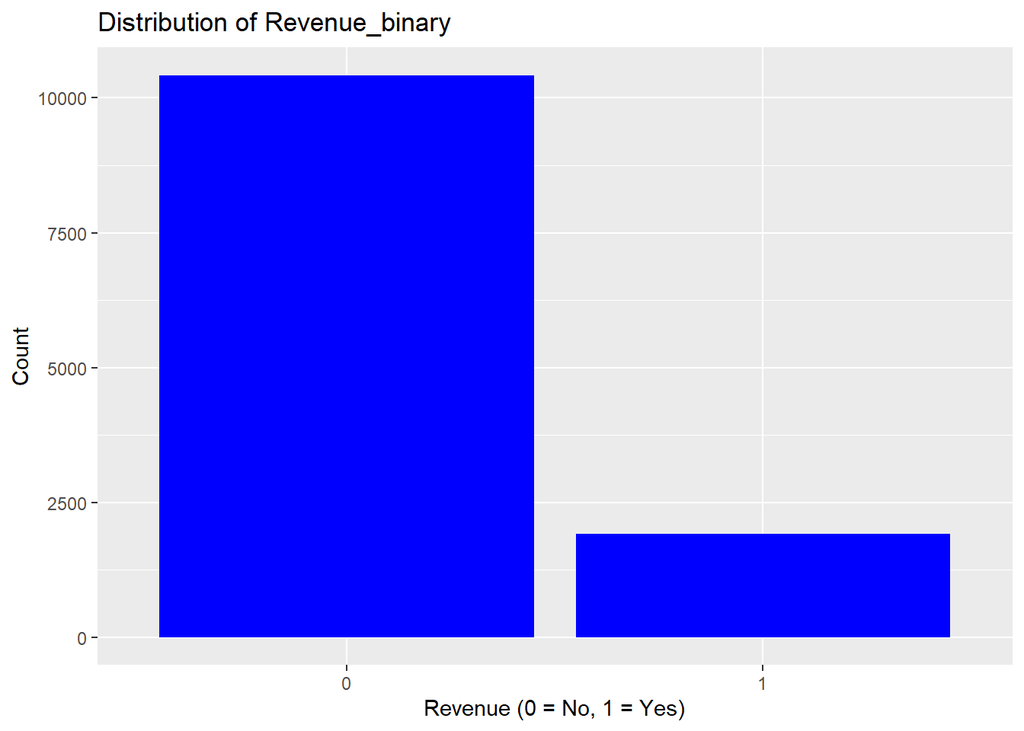

```r
# Plot distribution of Revenue_binary

ggplot(data, aes(x = Revenue_binary)) +
  geom_bar(fill = "blue") +
  labs(title = "Distribution of Revenue_binary", x = "Revenue (0 = No, 1 = Yes)", y = "Count")
```

> This chart shows a big imbalance: most sessions didn’t lead to purchases (0), while only a small number did (1). This is common in e-commerce but means we need to be careful when building models, as this imbalance could skew results. It also suggests there’s room to improve strategies to boost conversions

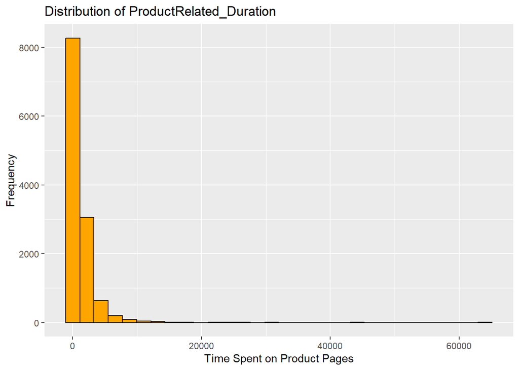

```r
# Histogram for ProductRelated_Duration
ggplot(data, aes(x = ProductRelated_Duration)) +
  geom_histogram(bins = 30, fill = "orange", color = "black") +
  labs(title = "Distribution of ProductRelated_Duration", x = "Time Spent on Product Pages", y = "Frequency")
```

> This chart shows the distribution of time visitors spent on product-related pages. Most visitors spent very little time, with the majority clustered near zero. There are a few sessions with significantly higher durations, indicating outliers. This skewed distribution suggests that many users may browse briefly, but only a small group engages deeply with product-related content.

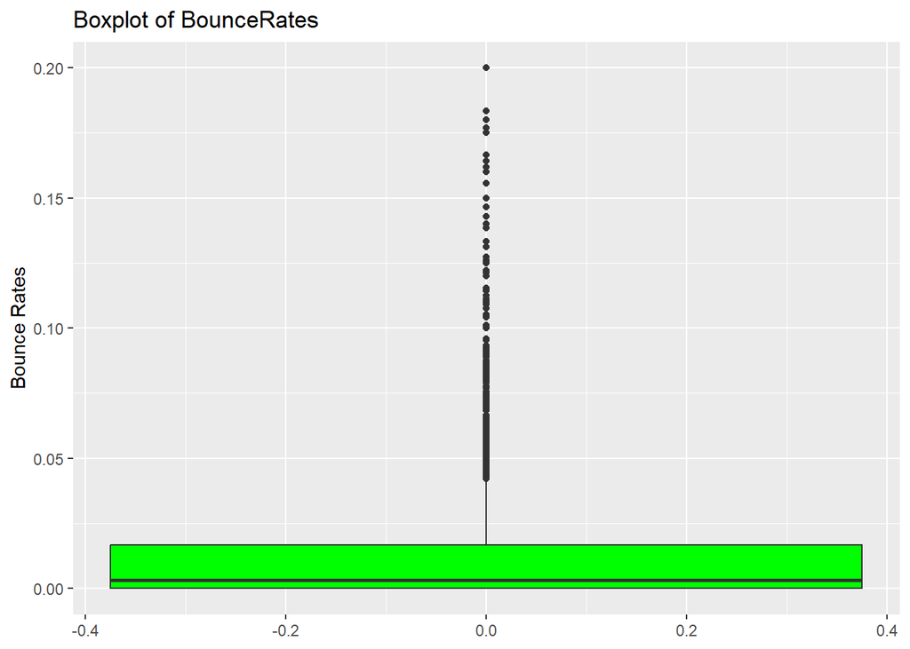

```r
# Boxplot for BounceRates
ggplot(data, aes(y = BounceRates)) +
  geom_boxplot(fill = "green") +
  labs(title = "Boxplot of BounceRates", y = "Bounce Rates")
```

> This boxplot shows that most sessions have very low bounce rates, meaning visitors tend to explore more than one page. However, there are some sessions with much higher bounce rates (the dots above), where users leave after just one page. These outliers might point to specific issues with certain pages or user experiences that need attention.

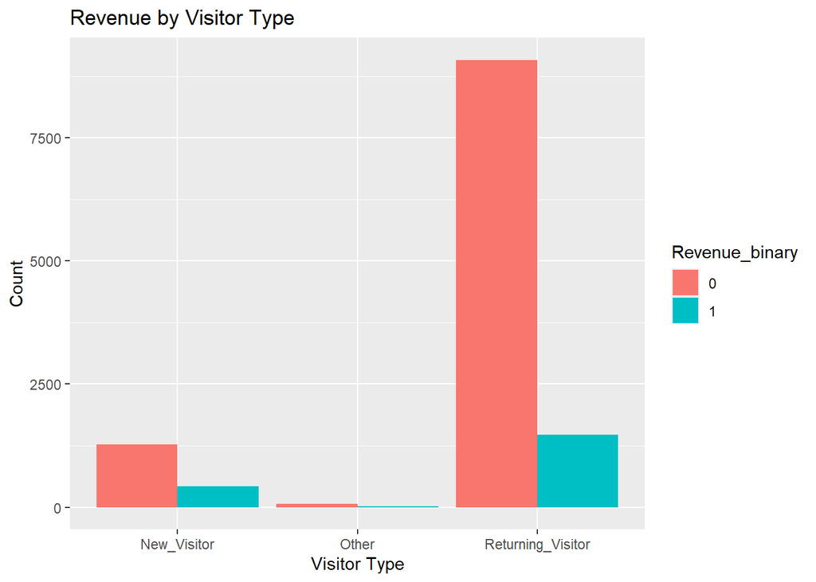

```r
# Revenue vs VisitorType

ggplot(data, aes(x = VisitorType, fill = Revenue_binary)) +
  geom_bar(position = "dodge") +
  labs(title = "Revenue by Visitor Type", x = "Visitor Type", y = "Count")
```

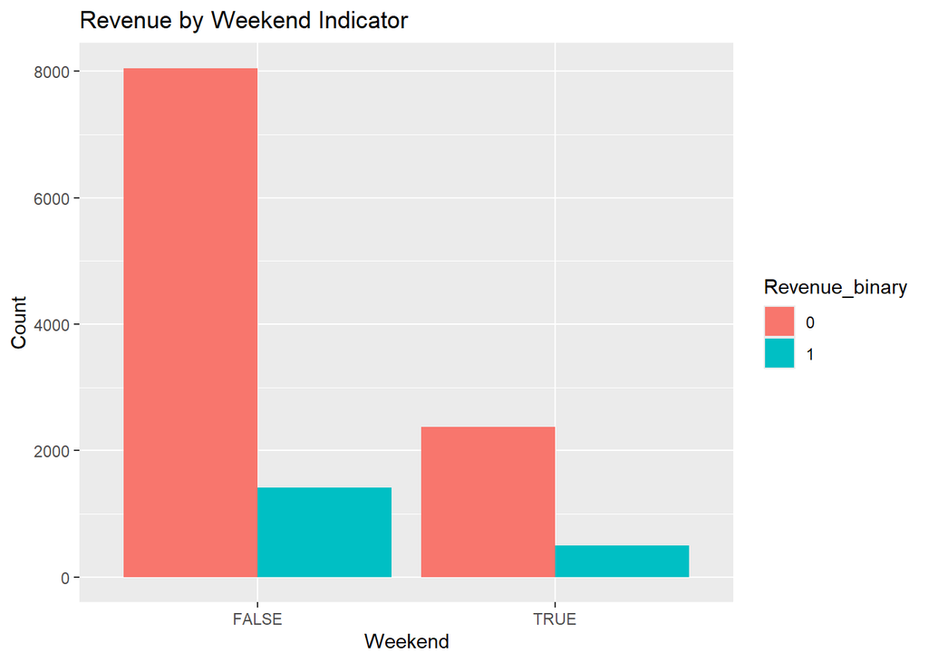

```r
# Revenue vs Weekend
ggplot(data, aes(x = Weekend, fill = Revenue_binary)) +
  geom_bar(position = "dodge") +
  labs(title = "Revenue by Weekend Indicator", x = "Weekend", y = "Count")
```

> This chart shows that most purchases (Revenue_binary = 1) happen during weekdays (Weekend = FALSE), as weekdays have a significantly higher count of transactions. While weekends (Weekend = TRUE) see fewer visits overall, there is still a noticeable portion of revenue-generating sessions. This suggests that e-commerce activity and purchases are more concentrated on weekdays, potentially due to users browsing and buying during workdays.

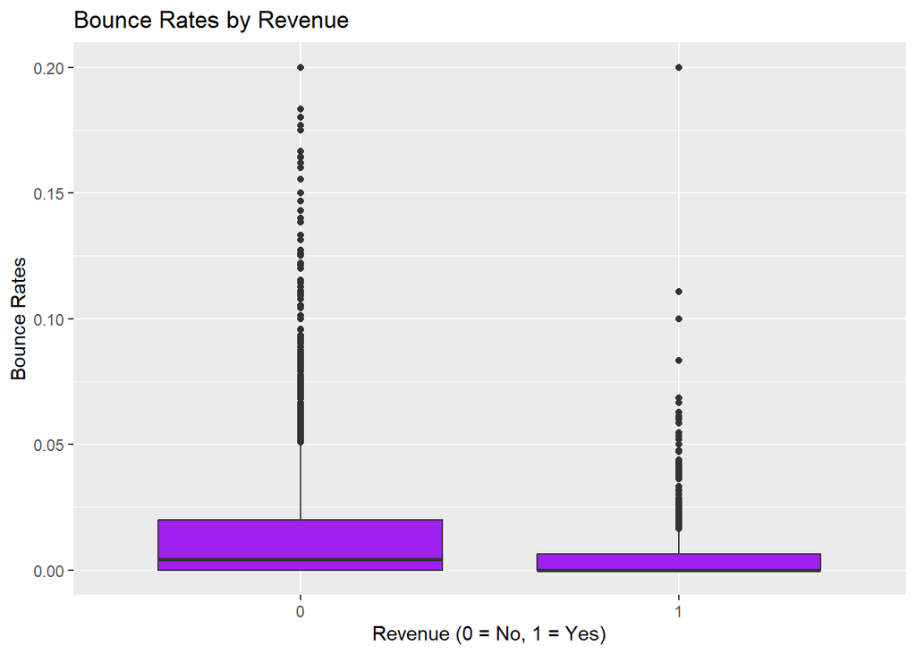

```r
# Revenue vs BounceRates
ggplot(data, aes(x = Revenue_binary, y = BounceRates)) +
  geom_boxplot(fill = "purple") +
  labs(title = "Bounce Rates by Revenue", x = "Revenue (0 = No, 1 = Yes)", y = "Bounce Rates")
```

> This chart shows that sessions with no purchases (0) tend to have higher bounce rates, meaning visitors often leave after viewing just one page. On the other hand, sessions with purchases (1) generally have much lower bounce rates, indicating that people who stick around and explore the site are more likely to buy something.

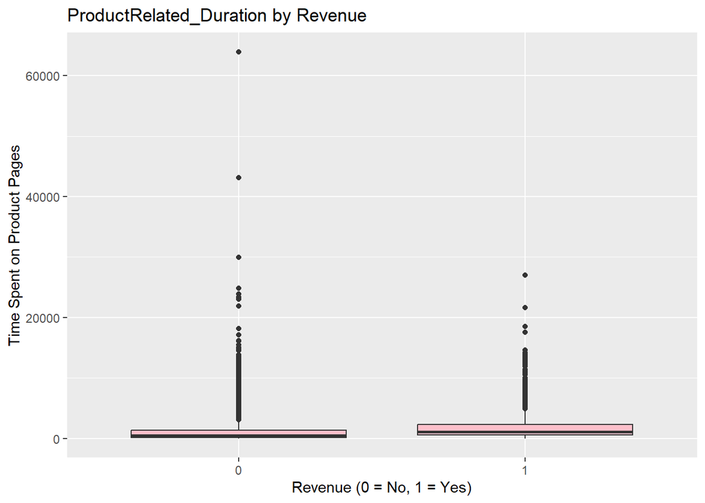

```r
# Revenue vs ProductRelated_Duration
ggplot(data, aes(x = Revenue_binary, y = ProductRelated_Duration)) +
  geom_boxplot(fill = "pink") +
  labs(title = "ProductRelated_Duration by Revenue", x = "Revenue (0 = No, 1 = Yes)", y = "Time Spent on Product Pages")
```

> This chart shows that people who make a purchase (1) usually spend more time on product pages compared to those who don’t (0). However, there’s still a lot of overlap between the two groups, meaning time spent on product pages isn’t the only factor that drives purchases. Still, the longer someone explores products, the more likely they are to buy.

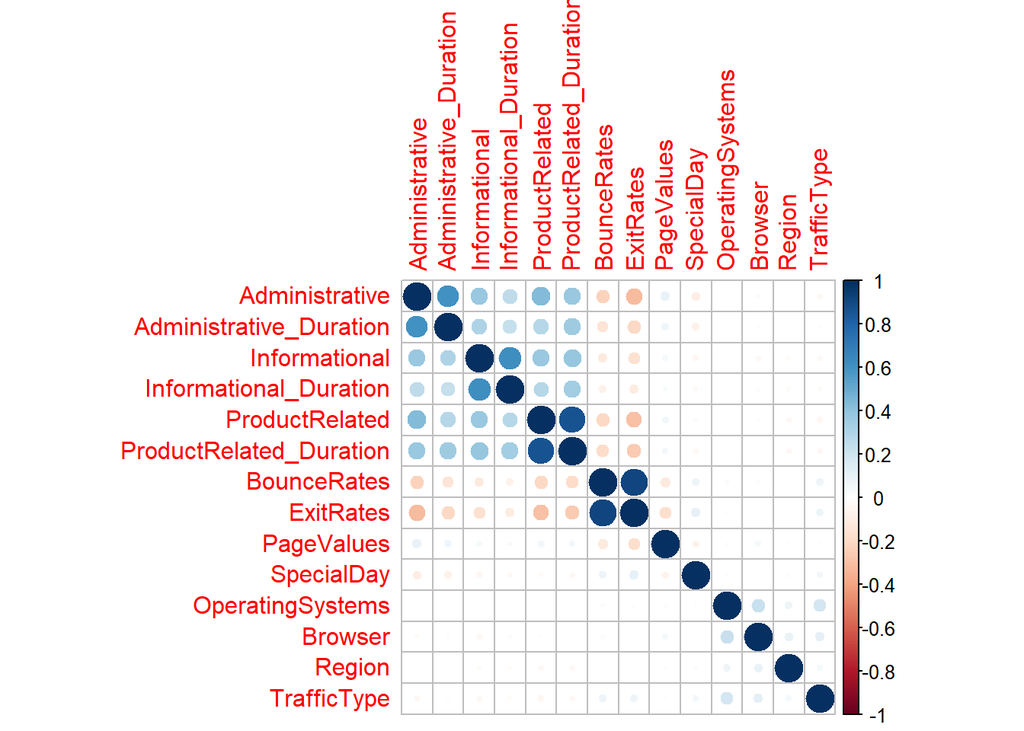

```r
# Identify numeric columns in the dataset
numeric_columns <- sapply(data , is.numeric)

# Compute the correlation matrix for numeric columns
corr_mat <- cor(data [, numeric_columns], use = "complete.obs")

# Visualize the correlation matrix
library(corrplot)
corrplot(corr_mat, method = "circle")  # Change "circle" to "number", "color", etc., for different styles
```

```r
data <- select(data, -Revenue )
```

## Partitioning the data

```r
# Partition the data: 80% training and 20% testing

set.seed(17)
trainIndex <- createDataPartition(data$Revenue_binary, p = 0.8,
                                  list = FALSE,
                                  times = 1)

# Create training and testing datasets
data_train <- data[as.vector(trainIndex), ]
data_test <- data[-as.vector(trainIndex), ]
```

As the classes of the target variable are imbalanced, checking if a similar proportion of both classes are present in the training and the test dataset.

```r
# Validate the distribution of Revenue_binary in the training set
table(data_train$Revenue_binary)
```

```
##
##    0    1
## 8338 1527
```

```r
prop.table(table(data_train$Revenue_binary))
```

```
##
##         0         1
## 0.8452103 0.1547897
```

```r
# Validate the distribution of Revenue_binary in the test set
table(data_test$Revenue_binary)
```

```
##
##    0    1
## 2084  381
```

```r
prop.table(table(data_test$Revenue_binary))
```

```
##
##         0         1
## 0.8454361 0.1545639
```

## Building and evaluation of predictive classification models

### Model 1 : Null model

```r
# Null model for training data
model_train_null <- rep(0, nrow(data_train))
model_train_null <- factor(model_train_null, levels = levels(data_train$Revenue_binary))

# Null model for test data
model_test_null <- rep(0, nrow(data_test))
model_test_null <- factor(model_test_null, levels = levels(data_test$Revenue_binary))

# Confusion matrices for training and test sets
cm_train_null <- confusionMatrix(model_train_null, data_train$Revenue_binary, positive = "1")
cm_test_null <- confusionMatrix(model_test_null, data_test$Revenue_binary, positive = "1")

# Print the confusion matrices
print("Confusion Matrix for Training Data (Null Model):")
```

```
## [1] "Confusion Matrix for Training Data (Null Model):"
```

```r
print(cm_train_null)
```

```
## Confusion Matrix and Statistics
##
##           Reference
## Prediction    0    1
##          0 8338 1527
##          1    0    0
##
##                Accuracy : 0.8452
##                  95% CI : (0.8379, 0.8523)
##     No Information Rate : 0.8452
##     P-Value [Acc > NIR] : 0.5068
##
##                   Kappa : 0
##
##  Mcnemar's Test P-Value : <2e-16
##
##             Sensitivity : 0.0000
##             Specificity : 1.0000
##          Pos Pred Value :    NaN
##          Neg Pred Value : 0.8452
##              Prevalence : 0.1548
##          Detection Rate : 0.0000
##    Detection Prevalence : 0.0000
##       Balanced Accuracy : 0.5000
##
##        'Positive' Class : 1
##
```

```r
print("Confusion Matrix for Test Data (Null Model):")
```

```
## [1] "Confusion Matrix for Test Data (Null Model):"
```

```r
print(cm_test_null)
```

```
## Confusion Matrix and Statistics
##
##           Reference
## Prediction    0    1
##          0 2084  381
##          1    0    0
##
##                Accuracy : 0.8454
##                  95% CI : (0.8306, 0.8595)
##     No Information Rate : 0.8454
##     P-Value [Acc > NIR] : 0.5137
##
##                   Kappa : 0
##
##  Mcnemar's Test P-Value : <2e-16
##
##             Sensitivity : 0.0000
##             Specificity : 1.0000
##          Pos Pred Value :    NaN
##          Neg Pred Value : 0.8454
##              Prevalence : 0.1546
##          Detection Rate : 0.0000
##    Detection Prevalence : 0.0000
##       Balanced Accuracy : 0.5000
##
##        'Positive' Class : 1
##
```

> The null model assumes no one makes a purchase, which gives a high accuracy (84.5%) because most sessions don’t result in revenue. However, it completely misses all purchases (sensitivity = 0%), making it useless for predicting buyers. This is just a starting point to compare better models that can actually identify sessions with purchases.

### Model 2.1 : Logistic Regression

```r
# Logistic regression model
Model_LR <- glm(Revenue_binary ~ Month + OperatingSystems + Browser + Region +
                TrafficType + VisitorType + Weekend + Administrative +
                Administrative_Duration + Informational + Informational_Duration +
                ProductRelated + ProductRelated_Duration + BounceRates +
                ExitRates + PageValues + SpecialDay,
                data = data_train, family = binomial(link = "logit"))
```

```r
LR_fittedclass <- (Model_LR$fitted.values > 0.5)*1
```

```r
# Evaluate the Model on Training Data
LR1_Train_CM <- confusionMatrix(as.factor(LR_fittedclass), as.factor(data_train$Revenue_binary), positive="1")
LR1_Train_CM
```

```
## Confusion Matrix and Statistics
##
##           Reference
## Prediction    0    1
##          0 8149  915
##          1  189  612
##
##                Accuracy : 0.8881
##                  95% CI : (0.8817, 0.8942)
##     No Information Rate : 0.8452
##     P-Value [Acc > NIR] : < 2.2e-16
##
##                   Kappa : 0.4692
##
##  Mcnemar's Test P-Value : < 2.2e-16
##
##             Sensitivity : 0.40079
##             Specificity : 0.97733
##          Pos Pred Value : 0.76404
##          Neg Pred Value : 0.89905
##              Prevalence : 0.15479
##          Detection Rate : 0.06204
##    Detection Prevalence : 0.08120
##       Balanced Accuracy : 0.68906
##
##        'Positive' Class : 1
##
```

```r
# Fit the Model on Test Data
Model_LR1 <- glm(Revenue_binary ~ Month + OperatingSystems + Browser + Region +
                 TrafficType + VisitorType + Weekend + Administrative +
                 Administrative_Duration + Informational + Informational_Duration +
                 ProductRelated + ProductRelated_Duration + BounceRates +
                 ExitRates + PageValues + SpecialDay,
                 data = data_test, family = binomial(link = "logit"), control = glm.control(maxit = 100))
```

```r
# Predict on Test Data and Evaluate
LR1_Pred <- predict(Model_LR1, type = "response")
LR1_Pred_Class <- (LR1_Pred > 0.5)*1

LR1_Test_CM <- confusionMatrix(as.factor(LR1_Pred_Class), as.factor(data_test$Revenue_binary), positive="1")
LR1_Test_CM
```

```
## Confusion Matrix and Statistics
##
##           Reference
## Prediction    0    1
##          0 2035  252
##          1   49  129
##
##                Accuracy : 0.8779
##                  95% CI : (0.8643, 0.8906)
##     No Information Rate : 0.8454
##     P-Value [Acc > NIR] : 2.532e-06
##
##                   Kappa : 0.4027
##
##  Mcnemar's Test P-Value : < 2.2e-16
##
##             Sensitivity : 0.33858
##             Specificity : 0.97649
##          Pos Pred Value : 0.72472
##          Neg Pred Value : 0.88981
##              Prevalence : 0.15456
##          Detection Rate : 0.05233
##    Detection Prevalence : 0.07221
##       Balanced Accuracy : 0.65754
##
##        'Positive' Class : 1
##
```

> The model achieves an accuracy of 87.79%, outperforming the baseline for thr Null model ( 84.5%) and showing excellent specificity (97.65%) in identifying no-purchase sessions. However, it struggles with sensitivity, detecting only 33.86% of actual purchases, reflecting difficulty in handling the minority class. Precision for predicting purchases is reasonable at 72.47%, but the model remains biased towards the majority class

### Model 2.1: Logistic Regression with Important Variables

```r
# Logistic regression model with important variables
Model_LR_important <- glm(Revenue_binary ~ PageValues + ExitRates +
                          ProductRelated_Duration + ProductRelated +
                          Month + BounceRates + Administrative_Duration +
                          Administrative,
                          data = data_train, family = binomial(link = "logit"))

# Evaluate the model on training data
LR_fittedclass_important <- (Model_LR_important$fitted.values > 0.5) * 1

# Confusion matrix for training data
LR1_Train_CM_important <- confusionMatrix(
  as.factor(LR_fittedclass_important),
  as.factor(data_train$Revenue_binary),
  positive = "1"
)
print(LR1_Train_CM_important)
```

```
## Confusion Matrix and Statistics
##
##           Reference
## Prediction    0    1
##          0 8144  916
##          1  194  611
##
##                Accuracy : 0.8875
##                  95% CI : (0.8811, 0.8937)
##     No Information Rate : 0.8452
##     P-Value [Acc > NIR] : < 2.2e-16
##
##                   Kappa : 0.4671
##
##  Mcnemar's Test P-Value : < 2.2e-16
##
##             Sensitivity : 0.40013
##             Specificity : 0.97673
##          Pos Pred Value : 0.75901
##          Neg Pred Value : 0.89890
##              Prevalence : 0.15479
##          Detection Rate : 0.06194
##    Detection Prevalence : 0.08160
##       Balanced Accuracy : 0.68843
##
##        'Positive' Class : 1
##
```

```r
# Logistic regression on test data
Model_LR1_important <- glm(Revenue_binary ~ PageValues + ExitRates +
                           ProductRelated_Duration + ProductRelated +
                           Month + BounceRates + Administrative_Duration +
                           Administrative,
                           data = data_test, family = binomial(link = "logit"),
                           control = glm.control(maxit = 100))

# Predict on test data and evaluate
LR1_Pred_important <- predict(Model_LR1_important, type = "response")
LR1_Pred_Class_important <- (LR1_Pred_important > 0.5) * 1

# Confusion matrix for test data
LR1_Test_CM_important <- confusionMatrix(
  as.factor(LR1_Pred_Class_important),
  as.factor(data_test$Revenue_binary),
  positive = "1"
)
print(LR1_Test_CM_important)
```

```
## Confusion Matrix and Statistics
##
##           Reference
## Prediction    0    1
##          0 2037  256
##          1   47  125
##
##                Accuracy : 0.8771
##                  95% CI : (0.8635, 0.8898)
##     No Information Rate : 0.8454
##     P-Value [Acc > NIR] : 4.427e-06
##
##                   Kappa : 0.3938
##
##  Mcnemar's Test P-Value : < 2.2e-16
##
##             Sensitivity : 0.32808
##             Specificity : 0.97745
##          Pos Pred Value : 0.72674
##          Neg Pred Value : 0.88836
##              Prevalence : 0.15456
##          Detection Rate : 0.05071
##    Detection Prevalence : 0.06978
##       Balanced Accuracy : 0.65277
##
##        'Positive' Class : 1
##
```

### Model 3 : Decision Tree with all variables

```r
# Train a decision tree model on the training dataset
#model_tree1 <- rpart(Revenue_binary ~ ., data = data_train)
model_tree1 <- rpart(Revenue_binary ~ Month + OperatingSystems + Browser + Region +
                TrafficType + VisitorType + Weekend + Administrative +
                Administrative_Duration + Informational + Informational_Duration +
                ProductRelated + ProductRelated_Duration + BounceRates +
                ExitRates + PageValues + SpecialDay,data = data_train)

# Predict class labels on the training dataset
class_train_tree1 <- predict(model_tree1, type = "class")

# Evaluate the model using a confusion matrix
cm_train_tree1 <- confusionMatrix(as.factor(class_train_tree1), as.factor(data_train$Revenue_binary), positive = "1")

# Display the confusion matrix
cm_train_tree1
```

```
## Confusion Matrix and Statistics
##
##           Reference
## Prediction    0    1
##          0 7867  473
##          1  471 1054
##
##                Accuracy : 0.9043
##                  95% CI : (0.8983, 0.91)
##     No Information Rate : 0.8452
##     P-Value [Acc > NIR] : <2e-16
##
##                   Kappa : 0.6341
##
##  Mcnemar's Test P-Value : 0.974
##
##             Sensitivity : 0.6902
##             Specificity : 0.9435
##          Pos Pred Value : 0.6911
##          Neg Pred Value : 0.9433
##              Prevalence : 0.1548
##          Detection Rate : 0.1068
##    Detection Prevalence : 0.1546
##       Balanced Accuracy : 0.8169
##
##        'Positive' Class : 1
##
```

> The decision tree model shows good overall accuracy (90.43%) and excels in identifying no-purchase sessions (specificity: 94.35%) but struggles to detect purchases, with a moderate sensitivity of 69.02%. This indicates the model is biased toward the majority class (no purchases). The Kappa score (0.6341) suggests moderate agreement beyond chance

```r
# Predict class labels on the test dataset
pred_tree1 <- predict(model_tree1, newdata = data_test, type = "class")

# Evaluate the model using a confusion matrix on the test dataset
cm_test_tree1 <- confusionMatrix(as.factor(pred_tree1), as.factor(data_test$Revenue_binary), positive = "1")

# Display the confusion matrix
cm_test_tree1
```

```
## Confusion Matrix and Statistics
##
##           Reference
## Prediction    0    1
##          0 1957  143
##          1  127  238
##
##                Accuracy : 0.8905
##                  95% CI : (0.8775, 0.9025)
##     No Information Rate : 0.8454
##     P-Value [Acc > NIR] : 6.326e-11
##
##                   Kappa : 0.5736
##
##  Mcnemar's Test P-Value : 0.3613
##
##             Sensitivity : 0.62467
##             Specificity : 0.93906
##          Pos Pred Value : 0.65205
##          Neg Pred Value : 0.93190
##              Prevalence : 0.15456
##          Detection Rate : 0.09655
##    Detection Prevalence : 0.14807
##       Balanced Accuracy : 0.78187
##
##        'Positive' Class : 1
##
```

> The decision tree model’s performance on the test dataset shows good overall accuracy (89.05%) and high specificity (93.91%), effectively identifying no-purchase sessions. However, its sensitivity (62.47%) indicates it misses nearly 38% of actual purchases.

### Model 3.1 : Decision Tree with with important variables

```r
# Train a decision tree model on the training dataset with important variables
model_tree1 <- rpart(Revenue_binary ~ BounceRates + ExitRates + PageValues +
                     ProductRelated_Duration + Administrative +
                     Informational_Duration + Month,
                     data = data_train)

# Predict class labels on the training dataset
class_train_tree1 <- predict(model_tree1, type = "class")

# Evaluate the model using a confusion matrix on the training dataset
cm_train_tree1 <- confusionMatrix(
  as.factor(class_train_tree1),
  as.factor(data_train$Revenue_binary),
  positive = "1"
)

# Display the confusion matrix for the training dataset
cm_train_tree1
```

```
## Confusion Matrix and Statistics
##
##           Reference
## Prediction    0    1
##          0 7885  525
##          1  453 1002
##
##                Accuracy : 0.9009
##                  95% CI : (0.8948, 0.9067)
##     No Information Rate : 0.8452
##     P-Value [Acc > NIR] : < 2e-16
##
##                   Kappa : 0.6137
##
##  Mcnemar's Test P-Value : 0.02319
##
##             Sensitivity : 0.6562
##             Specificity : 0.9457
##          Pos Pred Value : 0.6887
##          Neg Pred Value : 0.9376
##              Prevalence : 0.1548
##          Detection Rate : 0.1016
##    Detection Prevalence : 0.1475
##       Balanced Accuracy : 0.8009
##
##        'Positive' Class : 1
##
```

```r
# Predict class labels on the test dataset
pred_tree1 <- predict(model_tree1, newdata = data_test, type = "class")

# Evaluate the model using a confusion matrix on the test dataset
cm_test_tree1 <- confusionMatrix(
  as.factor(pred_tree1),
  as.factor(data_test$Revenue_binary),
  positive = "1"
)

# Display the confusion matrix for the test dataset
cm_test_tree1
```

```
## Confusion Matrix and Statistics
##
##           Reference
## Prediction    0    1
##          0 1961  155
##          1  123  226
##
##                Accuracy : 0.8872
##                  95% CI : (0.8741, 0.8994)
##     No Information Rate : 0.8454
##     P-Value [Acc > NIR] : 1.395e-09
##
##                   Kappa : 0.5531
##
##  Mcnemar's Test P-Value : 0.06299
##
##             Sensitivity : 0.59318
##             Specificity : 0.94098
##          Pos Pred Value : 0.64756
##          Neg Pred Value : 0.92675
##              Prevalence : 0.15456
##          Detection Rate : 0.09168
##    Detection Prevalence : 0.14158
##       Balanced Accuracy : 0.76708
##
##        'Positive' Class : 1
##
```

> The decision tree model performs well overall, with high accuracy (90.09% on training and 88.72% on testing) and specificity (94.57% and 94.10%, respectively), effectively identifying non-purchase sessions. However, sensitivity is moderate (65.62% on training and 59.32% on testing), indicating it struggles to detect a significant portion of actual purchases.

### Model 4.1 : Random Forest with all the variables

```r
# Train a Random Forest model
model_rf1 <- randomForest(Revenue_binary ~ ., data = data_train, importance = TRUE)

# Predict class labels on the training dataset
class_rf1 <- predict(model_rf1, type = "class")

# Evaluate the model using a confusion matrix
cm_train_rf1 <- confusionMatrix(as.factor(class_rf1), as.factor(data_train$Revenue_binary), positive = "1")

# Display the confusion matrix
cm_train_rf1
```

```
## Confusion Matrix and Statistics
##
##           Reference
## Prediction    0    1
##          0 8042  616
##          1  296  911
##
##                Accuracy : 0.9076
##                  95% CI : (0.9017, 0.9132)
##     No Information Rate : 0.8452
##     P-Value [Acc > NIR] : < 2.2e-16
##
##                   Kappa : 0.6136
##
##  Mcnemar's Test P-Value : < 2.2e-16
##
##             Sensitivity : 0.59659
##             Specificity : 0.96450
##          Pos Pred Value : 0.75476
##          Neg Pred Value : 0.92885
##              Prevalence : 0.15479
##          Detection Rate : 0.09235
##    Detection Prevalence : 0.12235
##       Balanced Accuracy : 0.78055
##
##        'Positive' Class : 1
##
```

> The Random Forest model demonstrates good overall accuracy (90.76%) and high specificity (96.45%), effectively identifying the majority class (no purchases). However, its sensitivity (59.66%) shows that it misses over 40% of actual purchases, indicating limited performance on the minority class..

```r
# Predict class labels on the test dataset
pred_rf1 <- predict(model_rf1, newdata = data_test, type = "class")

# Evaluate the model using a confusion matrix on the test dataset
cm_test_rf1 <- confusionMatrix(as.factor(pred_rf1), as.factor(data_test$Revenue_binary), positive = "1")

# Display the confusion matrix
cm_test_rf1
```

```
## Confusion Matrix and Statistics
##
##           Reference
## Prediction    0    1
##          0 2003  178
##          1   81  203
##
##                Accuracy : 0.8949
##                  95% CI : (0.8821, 0.9068)
##     No Information Rate : 0.8454
##     P-Value [Acc > NIR] : 5.862e-13
##
##                   Kappa : 0.5513
##
##  Mcnemar's Test P-Value : 2.444e-09
##
##             Sensitivity : 0.53281
##             Specificity : 0.96113
##          Pos Pred Value : 0.71479
##          Neg Pred Value : 0.91839
##              Prevalence : 0.15456
##          Detection Rate : 0.08235
##    Detection Prevalence : 0.11521
##       Balanced Accuracy : 0.74697
##
##        'Positive' Class : 1
##
```

### Model 4.2 : Random Forest model with important variables

```r
# Extracting variable importance from the Random Forest model
df_imp <- as.data.frame(model_rf1$importance) %>%
  arrange(desc(MeanDecreaseGini))  # Use MeanDecreaseGini for ranking

# Converting row names (variable names) into a column for easier plotting
df_imp <- tibble::rownames_to_column(df_imp, "variable")

# Display the importance data
print(df_imp)
```

```
##                   variable             0             1 MeanDecreaseAccuracy
## 1               PageValues  0.0672629178  0.3383982142         1.092651e-01
## 2                ExitRates  0.0094423685  0.0550279514         1.649507e-02
## 3  ProductRelated_Duration  0.0129477552  0.0114245687         1.271039e-02
## 4           ProductRelated  0.0120820115  0.0105792858         1.183986e-02
## 5                    Month -0.0008909967  0.0375610776         5.061589e-03
## 6  Administrative_Duration  0.0136634016 -0.0059655715         1.062616e-02
## 7              BounceRates  0.0073990335  0.0313860386         1.111031e-02
## 8           Administrative  0.0131648294 -0.0031475896         1.062590e-02
## 9              TrafficType  0.0008074552  0.0039258585         1.290204e-03
## 10                  Region -0.0000616520  0.0005471984         3.262131e-05
## 11  Informational_Duration  0.0029606788 -0.0010369074         2.339915e-03
## 12        OperatingSystems  0.0002923685  0.0012433142         4.362000e-04
## 13                 Browser  0.0004045690 -0.0008316410         2.126785e-04
## 14           Informational  0.0024894694  0.0002007506         2.132817e-03
```

[output cut: 21 more lines]

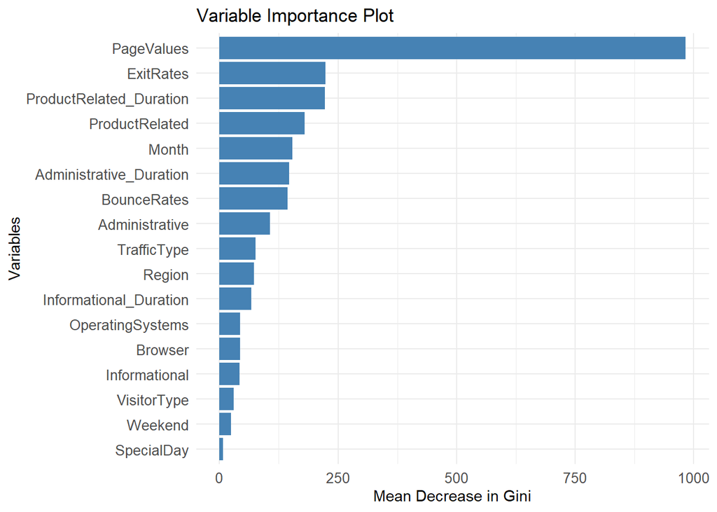

```r
# Plotting the variable importance
library(ggplot2)

ggplot(data = df_imp) +
  geom_bar(aes(x = reorder(variable, MeanDecreaseGini), y = MeanDecreaseGini),
           stat = "identity", fill = "steelblue") +
  coord_flip() +
  theme_minimal() +
  labs(title = "Variable Importance Plot",
       x = "Variables",
       y = "Mean Decrease in Gini") +
  theme(axis.text = element_text(size = 10))
```

> The plot shows PageValues, ExitRates, and ProductRelated_Duration as the most important variables for predicting revenue, highlighting user engagement and page value as key drivers. Less important features like SpecialDay and Weekend may have minimal impact and could be excluded for model simplification.

```r
# Subset the data with only the most important variables
important_vars <- c("PageValues", "ExitRates", "ProductRelated_Duration",
                    "ProductRelated", "Month", "BounceRates",
                    "Administrative_Duration", "Administrative", "TrafficType")

# Train a Random Forest model using only important variables
model_rf_important <- randomForest(
  Revenue_binary ~ .,
  data = data_train[, c(important_vars, "Revenue_binary")],
  importance = TRUE
)

# Predict class labels on the training dataset
class_rf_important_train <- predict(model_rf_important, type = "class")

# Evaluate the model on the training dataset
cm_train_rf_important <- confusionMatrix(
  as.factor(class_rf_important_train),
  as.factor(data_train$Revenue_binary),
  positive = "1"
)

# Print the confusion matrix for the training dataset
print(cm_train_rf_important)
```

```
## Confusion Matrix and Statistics
##
##           Reference
## Prediction    0    1
##          0 8005  595
##          1  333  932
##
##                Accuracy : 0.9059
##                  95% CI : (0.9, 0.9116)
##     No Information Rate : 0.8452
##     P-Value [Acc > NIR] : < 2.2e-16
##
##                   Kappa : 0.6134
##
##  Mcnemar's Test P-Value : < 2.2e-16
##
##             Sensitivity : 0.61035
##             Specificity : 0.96006
##          Pos Pred Value : 0.73676
##          Neg Pred Value : 0.93081
##              Prevalence : 0.15479
##          Detection Rate : 0.09448
##    Detection Prevalence : 0.12823
##       Balanced Accuracy : 0.78520
##
##        'Positive' Class : 1
##
```

```r
# Predict class labels on the test dataset
class_rf_important_test <- predict(model_rf_important, newdata = data_test[, c(important_vars, "Revenue_binary")], type = "class")

# Evaluate the model on the test dataset
cm_test_rf_important <- confusionMatrix(
  as.factor(class_rf_important_test),
  as.factor(data_test$Revenue_binary),
  positive = "1"
)

# Print the confusion matrix for the test dataset
print(cm_test_rf_important)
```

```
## Confusion Matrix and Statistics
##
##           Reference
## Prediction    0    1
##          0 1996  171
##          1   88  210
##
##                Accuracy : 0.8949
##                  95% CI : (0.8821, 0.9068)
##     No Information Rate : 0.8454
##     P-Value [Acc > NIR] : 5.862e-13
##
##                   Kappa : 0.5587
##
##  Mcnemar's Test P-Value : 3.483e-07
##
##             Sensitivity : 0.55118
##             Specificity : 0.95777
##          Pos Pred Value : 0.70470
##          Neg Pred Value : 0.92109
##              Prevalence : 0.15456
##          Detection Rate : 0.08519
##    Detection Prevalence : 0.12089
##       Balanced Accuracy : 0.75448
##
##        'Positive' Class : 1
##
```

### Model 4.3 : Random Forest model with class weights

```r
# Train a Random Forest model with class weights
model_rf_weighted <- randomForest(
  Revenue_binary ~ .,
  data = data_train,
  importance = TRUE,
  classwt = c("0" = 0.3, "1" = 0.7)  # Adjust weights as needed
)

# Predict class labels on the training dataset
class_rf_train_weighted <- predict(model_rf_weighted, type = "class")

# Evaluate the model using a confusion matrix on the training dataset
cm_train_rf_weighted <- confusionMatrix(
  as.factor(class_rf_train_weighted),
  as.factor(data_train$Revenue_binary),
  positive = "1"
)

# Display the confusion matrix for the training dataset
cm_train_rf_weighted
```

```
## Confusion Matrix and Statistics
##
##           Reference
## Prediction    0    1
##          0 8069  678
##          1  269  849
##
##                Accuracy : 0.904
##                  95% CI : (0.898, 0.9097)
##     No Information Rate : 0.8452
##     P-Value [Acc > NIR] : < 2.2e-16
##
##                   Kappa : 0.5881
##
##  Mcnemar's Test P-Value : < 2.2e-16
##
##             Sensitivity : 0.55599
##             Specificity : 0.96774
##          Pos Pred Value : 0.75939
##          Neg Pred Value : 0.92249
##              Prevalence : 0.15479
##          Detection Rate : 0.08606
##    Detection Prevalence : 0.11333
##       Balanced Accuracy : 0.76187
##
##        'Positive' Class : 1
##
```

```r
# Predict class labels on the test dataset
class_rf_test_weighted <- predict(model_rf_weighted, newdata = data_test, type = "class")

# Evaluate the model using a confusion matrix on the test dataset
cm_test_rf_weighted <- confusionMatrix(
  as.factor(class_rf_test_weighted),
  as.factor(data_test$Revenue_binary),
  positive = "1"
)

# Display the confusion matrix for the test dataset
cm_test_rf_weighted
```

```
## Confusion Matrix and Statistics
##
##           Reference
## Prediction    0    1
##          0 2009  180
##          1   75  201
##
##                Accuracy : 0.8966
##                  95% CI : (0.8839, 0.9083)
##     No Information Rate : 0.8454
##     P-Value [Acc > NIR] : 9.416e-14
##
##                   Kappa : 0.5539
##
##  Mcnemar's Test P-Value : 7.380e-11
##
##             Sensitivity : 0.52756
##             Specificity : 0.96401
##          Pos Pred Value : 0.72826
##          Neg Pred Value : 0.91777
##              Prevalence : 0.15456
##          Detection Rate : 0.08154
##    Detection Prevalence : 0.11197
##       Balanced Accuracy : 0.74579
##
##        'Positive' Class : 1
##
```

```r
# Apply undersampling to balance the training data
data_train_under <- ovun.sample(Revenue_binary ~ ., data = data_train, method = "under")$data

# Check the class distribution after undersampling
table(data_train_under$Revenue_binary)
```

```
##
##    0    1
## 1520 1527
```

```r
# Train Random Forest model on undersampled data
model_rf_under <- randomForest(
  Revenue_binary ~ .,
  data = data_train_under,
  importance = TRUE
)
```

```r
# Predict class labels on the test dataset
pred_rf_under <- predict(model_rf_under, newdata = data_test, type = "class")

# Evaluate the model using a confusion matrix
cm_test_rf_under <- confusionMatrix(
  as.factor(pred_rf_under),
  as.factor(data_test$Revenue_binary),
  positive = "1"
)

# Display the confusion matrix
cm_test_rf_under
```

```
## Confusion Matrix and Statistics
##
##           Reference
## Prediction    0    1
##          0 1782   69
##          1  302  312
##
##                Accuracy : 0.8495
##                  95% CI : (0.8348, 0.8634)
##     No Information Rate : 0.8454
##     P-Value [Acc > NIR] : 0.2999
##
##                   Kappa : 0.5392
##
##  Mcnemar's Test P-Value : <2e-16
##
##             Sensitivity : 0.8189
##             Specificity : 0.8551
##          Pos Pred Value : 0.5081
##          Neg Pred Value : 0.9627
##              Prevalence : 0.1546
##          Detection Rate : 0.1266
##    Detection Prevalence : 0.2491
##       Balanced Accuracy : 0.8370
##
##        'Positive' Class : 1
##
```

```r
table(data_test$Revenue_binary)
```

```
##
##    0    1
## 2084  381
```

```r
# Separate the majority and minority classes
majority_class <- data_test %>% filter(Revenue_binary == 0)
minority_class <- data_test %>% filter(Revenue_binary == 1)

# Randomly sample from the majority class to match the minority class size
set.seed(123)  # For reproducibility
majority_class_under <- majority_class %>% sample_n(nrow(minority_class))

# Combine the undersampled majority class with the minority class
data_test_balanced <- bind_rows(majority_class_under, minority_class)

# Shuffle the rows
data_test_balanced <- data_test_balanced %>% sample_frac(1)

# Check the class distribution
table(data_test_balanced$Revenue_binary)
```

```
##
##   0   1
## 381 381
```

```r
# Predict on the balanced test dataset
pred_rf_balanced <- predict(model_rf_under, newdata = data_test_balanced, type = "class")

# Evaluate using a confusion matrix
cm_test_balanced <- confusionMatrix(
  as.factor(pred_rf_balanced),
  as.factor(data_test_balanced$Revenue_binary),
  positive = "1"
)

# Display the confusion matrix
cm_test_balanced
```

```
## Confusion Matrix and Statistics
##
##           Reference
## Prediction   0   1
##          0 335  69
##          1  46 312
##
##                Accuracy : 0.8491
##                  95% CI : (0.8217, 0.8738)
##     No Information Rate : 0.5
##     P-Value [Acc > NIR] : < 2e-16
##
##                   Kappa : 0.6982
##
##  Mcnemar's Test P-Value : 0.04022
##
##             Sensitivity : 0.8189
##             Specificity : 0.8793
##          Pos Pred Value : 0.8715
##          Neg Pred Value : 0.8292
##              Prevalence : 0.5000
##          Detection Rate : 0.4094
##    Detection Prevalence : 0.4698
##       Balanced Accuracy : 0.8491
##
##        'Positive' Class : 1
##
```

## Model Comparison

```r
# Function to summarize confusion matrix results
cm_summary <- function(cm, label){
  sprintf("%s: Accuracy = %8.4f, Sensitivity = %8.4f, Specificity = %8.4f",
          label,
          cm$overall["Accuracy"],
          cm$byClass["Sensitivity"],
          cm$byClass["Specificity"])
}

# Comparing results on training dataset
print("Comparing the results on training dataset")
```

```
## [1] "Comparing the results on training dataset"
```

```r
cat(cm_summary(LR1_Train_CM, "Logistic Regression (All Variables)"), "\n")
```

```
## Logistic Regression (All Variables): Accuracy =   0.8881, Sensitivity =   0.4008, Specificity =   0.9773
```

```r
cat(cm_summary(LR1_Train_CM_important, "Logistic Regression (Important Variables)"), "\n")
```

```
## Logistic Regression (Important Variables): Accuracy =   0.8875, Sensitivity =   0.4001, Specificity =   0.9767
```

```r
cat(cm_summary(cm_train_tree1, "Decision Tree (All Variables)"), "\n")
```

[output not shown]

```r
cat(cm_summary(cm_train_rf1, "Random Forest (All Variables)"), "\n")
```

```
## Random Forest (All Variables): Accuracy =   0.9076, Sensitivity =   0.5966, Specificity =   0.9645
```

```r
cat(cm_summary(cm_train_rf_important, "Random Forest (Important Variables)"), "\n")
```

```
## Random Forest (Important Variables): Accuracy =   0.9059, Sensitivity =   0.6103, Specificity =   0.9601
```

```r
cat(cm_summary(cm_train_rf_weighted, "Random Forest (Weighted)"), "\n")
```

```
## Random Forest (Weighted): Accuracy =   0.9040, Sensitivity =   0.5560, Specificity =   0.9677
```

```r
# Comparing results on test dataset
print("Comparing the results on test dataset")
```

```
## [1] "Comparing the results on test dataset"
```

```r
cat(cm_summary(LR1_Test_CM, "Logistic Regression (All Variables)"), "\n")
```

```
## Logistic Regression (All Variables): Accuracy =   0.8779, Sensitivity =   0.3386, Specificity =   0.9765
```

```r
cat(cm_summary(LR1_Test_CM_important, "Logistic Regression (Important Variables)"), "\n")
```

```
## Logistic Regression (Important Variables): Accuracy =   0.8771, Sensitivity =   0.3281, Specificity =   0.9774
```

```r
cat(cm_summary(cm_test_tree1, "Decision Tree (All Variables)"), "\n")
```

[output not shown]

```r
cat(cm_summary(cm_test_rf1, "Random Forest (All Variables)"), "\n")
```

```
## Random Forest (All Variables): Accuracy =   0.8949, Sensitivity =   0.5328, Specificity =   0.9611
```

```r
cat(cm_summary(cm_test_rf_important, "Random Forest (Important Variables)"), "\n")
```

```
## Random Forest (Important Variables): Accuracy =   0.8949, Sensitivity =   0.5512, Specificity =   0.9578
```

```r
cat(cm_summary(cm_test_rf_weighted, "Random Forest (Weighted)"), "\n")
```

```
## Random Forest (Weighted): Accuracy =   0.8966, Sensitivity =   0.5276, Specificity =   0.9640
```

```r
cat(cm_summary(cm_test_rf_under, "Random Forest (Undersampled)"), "\n")
```

```
## Random Forest (Undersampled): Accuracy =   0.8495, Sensitivity =   0.8189, Specificity =   0.8551
```